# Hackathon : Neural network model applied for predictions

During this work, the purpose is to make prediction on a test set. In order to do this, we will first apply a **Deep Learning** model based on a **Neural Network** method and train this model thanks to a train set

**Librairies needed**

```python
#General librairies that we usually need
import matplotlib.pyplot as plt
import pandas as pd
import numpy as np

# Math librairies
import math
import random

# Data treatment librairies
from sklearn import preprocessing
from tensorflow.keras.utils import to_categorical
from sklearn.preprocessing import MinMaxScaler
from sklearn.model_selection import train_test_split

# Model of neural network librairies
import tensorflow as tf
from tensorflow.keras.models import Sequential
from tensorflow.keras.layers import Dense


# Improvement of our model librairies
from tensorflow.keras.losses import sparse_categorical_crossentropy
from tensorflow.keras.optimizers import SGD
from tensorflow.keras.layers import Dropout
from tensorflow.keras.optimizers import Adam
from tensorflow.keras import regularizers
```

## I) Dataset treatment

### Importation of the dataset

My student number is **710053**. Indeed, I chose the dataset number **3** because these is no dataset **53**.

I first treated the excel in order to have a first line that contains the titles of the columns and to not drop the first data during the importation

```python
data_train = pd.read_csv('phpYLeydd_train_3.csv',sep=',')
data_train
```

|  | x1 | x2 | x3 | x4 | x5 | x6 | x7 | x8 | x9 | x10 | ... | x24 | x25 | x26 | x27 | x28 | x29 | x30 | x31 | x32 | y |
| --- | --- | --- | --- | --- | --- | --- | --- | --- | --- | --- | --- | --- | --- | --- | --- | --- | --- | --- | --- | --- | --- |
| 0 | -0.010986 | -0.019268 | -0.004024 | 0.019540 | -0.027302 | -0.003749 | -0.006132 | -0.015922 | -0.002714 | 0.011511 | ... | 0.000488 | 0.022542 | 0.033783 | 0.017276 | 0.028320 | 0.002973 | 0.001524 | 0.002761 | 0.000803 | 'R' |
| 1 | 0.000068 | -0.000693 | 0.000129 | 0.003799 | -0.003345 | -0.000067 | 0.001003 | -0.001431 | 0.000201 | 0.001266 | ... | 0.000007 | 0.000709 | 0.005062 | 0.001759 | 0.001509 | 0.000045 | 0.000235 | 0.000216 | 0.000021 | 'D' |
| 2 | 0.005934 | 0.001838 | 0.000838 | -0.005607 | -0.000874 | 0.000326 | 0.006388 | 0.002147 | 0.000387 | -0.000824 | ... | 0.000034 | 0.006268 | 0.005684 | 0.006750 | 0.001103 | 0.000208 | 0.000565 | 0.000466 | 0.000300 | 'S' |
| 3 | -0.000210 | -0.000211 | -0.000056 | 0.000771 | -0.000891 | 0.000007 | -0.000225 | -0.000207 | -0.000054 | 0.001438 | ... | -0.000037 | 0.000303 | 0.001178 | 0.000310 | 0.001462 | 0.000080 | 0.000129 | 0.000077 | 0.000152 | 'H' |
| 4 | -0.001753 | 0.000202 | -0.000028 | -0.000212 | -0.000143 | 0.000088 | -0.000013 | -0.000160 | -0.000011 | -0.000196 | ... | 0.000028 | 0.001765 | 0.000271 | 0.000161 | 0.000260 | 0.000216 | 0.000108 | 0.000007 | 0.000086 | 'D' |
| ... | ... | ... | ... | ... | ... | ... | ... | ... | ... | ... | ... | ... | ... | ... | ... | ... | ... | ... | ... | ... | ... |
| 7864 | -0.009443 | 0.016555 | 0.002043 | 0.016966 | 0.005601 | 0.002325 | -0.010921 | 0.019394 | 0.001878 | 0.008865 | ... | -0.000452 | 0.019168 | 0.018018 | 0.022336 | 0.009804 | 0.000985 | 0.002279 | 0.001483 | 0.001434 | 'P' |
| 7865 | 0.002022 | -0.001010 | -0.000952 | 0.000252 | -0.002550 | 0.000240 | 0.001602 | 0.000323 | -0.000903 | 0.000112 | ... | 0.000152 | 0.002453 | 0.002574 | 0.001867 | 0.002183 | 0.000472 | 0.000511 | 0.000358 | 0.000386 | 'P' |
| 7866 | -0.003163 | 0.012324 | 0.000267 | 0.004192 | 0.009433 | 0.004149 | -0.001644 | 0.008568 | 0.000635 | -0.002771 | ... | -0.000090 | 0.012726 | 0.011125 | 0.008748 | 0.003077 | 0.002122 | 0.000755 | 0.000840 | 0.002202 | 'P' |
| 7867 | 0.000099 | -0.001351 | -0.000014 | -0.000767 | -0.002259 | 0.000483 | 0.000780 | -0.001344 | -0.000107 | -0.001451 | ... | -0.000003 | 0.001355 | 0.002434 | 0.001558 | 0.002239 | 0.000076 | 0.000918 | 0.000057 | 0.000868 | 'S' |
| 7868 | -0.008997 | -0.030975 | -0.003181 | -0.000335 | -0.004185 | 0.000594 | -0.000837 | -0.020098 | -0.002178 | 0.001086 | ... | -0.000104 | 0.032412 | 0.004240 | 0.020233 | 0.001294 | 0.005159 | 0.002353 | 0.005165 | 0.002342 | 'S' |

7869 rows × 33 columns

```python
data_train.info()
```

```
<class 'pandas.core.frame.DataFrame'>
RangeIndex: 7869 entries, 0 to 7868
Data columns (total 33 columns):
 #   Column  Non-Null Count  Dtype
---  ------  --------------  -----
 0   x1      7869 non-null   float64
 1   x2      7869 non-null   float64
 2   x3      7869 non-null   float64
 3   x4      7869 non-null   float64
 4   x5      7869 non-null   float64
 5   x6      7869 non-null   float64
 6   x7      7869 non-null   float64
 7   x8      7869 non-null   float64
 8   x9      7869 non-null   float64
 9   x10     7869 non-null   float64
```

[output cut: 25 more lines]

```python
data_train.shape
```

```
(7869, 33)
```

We have 32 **features** (X) and 1 **layer** (y) to predict for a total of 7869 data.

```python
data_train['y'].unique()
```

```
array(["'R'", "'D'", "'S'", "'H'", "'P'"], dtype=object)
```

```python
data_train['y'].nunique()
```

```
5
```

So we have **5 labels**

I decide to convert the labels into **numeric values**. It would be easier to work on it. Each number from 1 to 5 corresponds to a class.

```python
data_train['y'] = data_train['y'].replace("'R'", 1)
data_train['y'] = data_train['y'].replace("'D'", 2)
data_train['y'] = data_train['y'].replace("'S'", 3)
data_train['y'] = data_train['y'].replace("'H'", 4)
data_train['y'] = data_train['y'].replace("'P'", 5)
```

### Visualization

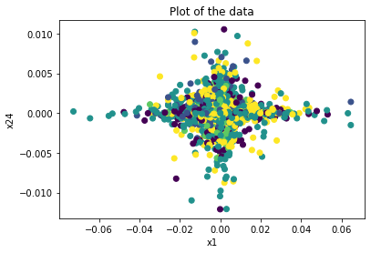

```python
plt.scatter(
    data_train['x1'],
    data_train['x24'],
    c = data_train['y'],
    cmap='viridis')
plt.xlabel('x1')
plt.ylabel('x24')
plt.title('Plot of the data')
plt.show()
```

We plot the data according to 2 features x1 and x24.

### Convert the dataset into a matrix

We have imported the train dataset. We have now to treat it in order to work on it. First, we have to store our values in arrays. Matrix are much easier to use and simplify maths used for the model and is much more faster to compile.

```python
X_train = data_train.iloc[:,:data_train.shape[1]-1]
X_train = X_train.values
print('X :',X_train)
```

```
X : [[-1.098642e-02 -1.926751e-02 -4.023590e-03 ...  1.524330e-03
   2.760560e-03  8.031900e-04]
 [ 6.814000e-05 -6.934600e-04  1.288600e-04 ...  2.352700e-04
   2.157800e-04  2.066000e-05]
 [ 5.933850e-03  1.837940e-03  8.381800e-04 ...  5.646000e-04
   4.658700e-04  2.999300e-04]
 ...
 [-3.163250e-03  1.232357e-02  2.671600e-04 ...  7.547800e-04
   8.402700e-04  2.201910e-03]
 [ 9.873000e-05 -1.351070e-03 -1.416000e-05 ...  9.183900e-04
   5.685000e-05  8.678500e-04]
 [-8.996790e-03 -3.097527e-02 -3.181380e-03 ...  2.353470e-03
   5.165190e-03  2.341610e-03]]
```

```python
Y_train = data_train.iloc[:,-1]
Y_train
print('Y :\n',Y_train)
```

```
Y :
 0       1
1       2
2       3
3       4
4       2
       ..
7864    5
7865    5
7866    5
7867    3
7868    3
Name: y, Length: 7869, dtype: int64
```

```python
print('X_train shape :',X_train.shape)

print('Y_train shape :',Y_train.shape)
```

```
X_train shape : (7869, 32)
Y_train shape : (7869,)
```

We have now 2 arrays with the good shape:

- **X** : features
- **Y** : layer to predict

### Pre processing and scaling

```python
min_max_scaler = preprocessing.MinMaxScaler()
X_train = min_max_scaler.fit_transform(X_train)
X_train
```

```
array([[4.48902264e-01, 3.97466376e-01, 4.58787208e-01, ...,
        1.65075760e-02, 7.01710990e-02, 1.09177318e-02],
       [5.29417313e-01, 5.20629543e-01, 4.82357753e-01, ...,
        2.54517612e-03, 5.47721142e-03, 2.77518751e-04],
       [5.72139767e-01, 5.37415071e-01, 4.86384065e-01, ...,
        6.11230035e-03, 1.18350476e-02, 4.07480742e-03],
       ...,
       [5.05881729e-01, 6.06944517e-01, 4.83142785e-01, ...,
        8.17222712e-03, 2.13531165e-02, 2.99364005e-02],
       [5.29640113e-01, 5.16268979e-01, 4.81545928e-01, ...,
        9.94436205e-03, 1.43686233e-03, 1.17969264e-02],
       [4.63393583e-01, 3.19833076e-01, 4.63567843e-01, ...,
        2.54883715e-02, 1.31302066e-01, 3.18359286e-02]])
```

```python
Y_train = to_categorical(Y_train)
Y_train = np.delete(Y_train,[0],1)
Y_train
```

```
array([[1., 0., 0., 0., 0.],
       [0., 1., 0., 0., 0.],
       [0., 0., 1., 0., 0.],
       ...,
       [0., 0., 0., 0., 1.],
       [0., 0., 1., 0., 0.],
       [0., 0., 1., 0., 0.]], dtype=float32)
```

We use the **hot encoding method** for the label. It create a matrix with 5 columns (number of labels). If a data belongs to a label, the value corresponding to the index of will be 1 and the rest will be evaluated to 0. For example, we can see that the first data belong to label 1 ('R'), the last one to label 3('S').

### Import and treat the test set

```python
data_test = pd.read_csv('phpYLeydd_test.csv',sep=',')
data_test['y'] = data_test['y'].replace("'R'", 1)
data_test['y'] = data_test['y'].replace("'D'", 2)
data_test['y'] = data_test['y'].replace("'S'", 3)
data_test['y'] = data_test['y'].replace("'H'", 4)
data_test['y'] = data_test['y'].replace("'P'", 5)
data_test
```

|  | x1 | x2 | x3 | x4 | x5 | x6 | x7 | x8 | x9 | x10 | ... | x24 | x25 | x26 | x27 | x28 | x29 | x30 | x31 | x32 | y |
| --- | --- | --- | --- | --- | --- | --- | --- | --- | --- | --- | --- | --- | --- | --- | --- | --- | --- | --- | --- | --- | --- |
| 0 | -0.024427 | 0.006105 | -0.009190 | 0.009911 | 0.003952 | 0.022503 | -0.020666 | 0.008078 | -0.006453 | 0.009038 | ... | -0.004229 | 0.026803 | 0.024904 | 0.023108 | 0.029646 | 0.003597 | 0.006373 | 0.005610 | 0.005071 | 3 |
| 1 | -0.004975 | 0.037317 | -0.000169 | -0.008475 | -0.018003 | 0.000343 | -0.000847 | 0.029391 | -0.000093 | -0.005268 | ... | -0.000122 | 0.037648 | 0.019901 | 0.029403 | 0.013098 | 0.000730 | 0.000695 | 0.001130 | 0.000547 | 3 |
| 2 | 0.004199 | -0.004871 | 0.007259 | 0.004396 | -0.007048 | 0.008402 | 0.006191 | -0.010978 | 0.007110 | 0.003973 | ... | 0.000269 | 0.009698 | 0.011815 | 0.014471 | 0.010892 | 0.009148 | 0.002981 | 0.003567 | 0.003362 | 3 |
| 3 | -0.000579 | -0.004085 | 0.000015 | -0.011690 | -0.000814 | -0.001949 | 0.000248 | 0.001156 | 0.000126 | -0.011016 | ... | 0.000103 | 0.004126 | 0.011879 | 0.001189 | 0.011276 | 0.000106 | 0.000660 | 0.000123 | 0.000617 | 3 |
| 4 | -0.002929 | -0.001741 | -0.000287 | 0.004772 | -0.012481 | 0.002615 | -0.006595 | -0.002301 | 0.000360 | -0.001412 | ... | -0.000161 | 0.003420 | 0.013616 | 0.006994 | 0.010282 | 0.000164 | 0.001123 | 0.000647 | 0.002208 | 5 |
| ... | ... | ... | ... | ... | ... | ... | ... | ... | ... | ... | ... | ... | ... | ... | ... | ... | ... | ... | ... | ... | ... |
| 1999 | 0.000444 | -0.000855 | -0.000432 | 0.003102 | -0.000173 | 0.000014 | 0.000028 | 0.000745 | -0.000316 | -0.000027 | ... | 0.000004 | 0.001056 | 0.003107 | 0.000809 | 0.000464 | 0.000177 | 0.000283 | 0.000140 | 0.000266 | 2 |
| 2000 | 0.005760 | -0.006641 | -0.002260 | -0.002855 | -0.008738 | -0.002295 | 0.002331 | -0.006528 | -0.001527 | -0.000823 | ... | -0.000075 | 0.009077 | 0.009474 | 0.007098 | 0.006503 | 0.000968 | 0.000604 | 0.000565 | 0.000234 | 1 |
| 2001 | 0.000167 | -0.025493 | -0.000543 | 0.003275 | 0.001768 | -0.000491 | 0.000414 | -0.020334 | 0.000153 | 0.002887 | ... | -0.000038 | 0.025500 | 0.003754 | 0.020339 | 0.003090 | 0.000472 | 0.000481 | 0.000775 | 0.000285 | 5 |
| 2002 | -0.001842 | -0.004095 | 0.000595 | -0.025661 | 0.003843 | 0.000059 | -0.001862 | -0.004079 | 0.000603 | -0.023326 | ... | 0.000142 | 0.004530 | 0.025947 | 0.004524 | 0.024267 | 0.008217 | 0.000405 | 0.007551 | 0.000896 | 3 |
| 2003 | 0.005914 | 0.005261 | -0.003142 | 0.000033 | 0.001207 | -0.000082 | -0.000261 | 0.003680 | -0.000800 | -0.003351 | ... | -0.000240 | 0.008516 | 0.001210 | 0.003775 | 0.004557 | 0.002490 | 0.000985 | 0.001179 | 0.000457 | 4 |

2004 rows × 33 columns

```python
X_test_val = data_test.iloc[:,:data_test.shape[1]-1]
X_test_val = X_test_val.values
print('X :',X_test_val)
```

```
X : [[-0.02442655  0.00610543 -0.00918982 ...  0.0063732   0.00560961
   0.00507109]
 [-0.00497514  0.03731698 -0.00016922 ...  0.0006945   0.00112998
   0.0005467 ]
 [ 0.00419865 -0.00487124  0.00725939 ...  0.00298148  0.00356726
   0.00336183]
 ...
 [ 0.00016689 -0.02549327 -0.00054342 ...  0.00048123  0.00077494
   0.00028477]
 [-0.00184236 -0.00409535  0.00059549 ...  0.00040539  0.00755097
   0.00089556]
 [ 0.00591366  0.00526072 -0.00314228 ...  0.00098529  0.00117932
   0.00045704]]
```

```python
min_max_scaler = preprocessing.MinMaxScaler()
X_test_val = min_max_scaler.fit_transform(X_test_val)
X_test_val
```

```
array([[0.23049805, 0.63824396, 0.42314045, ..., 0.25490539, 0.28373216,
        0.2845872 ],
       [0.38343047, 0.89079671, 0.47894753, ..., 0.02775793, 0.05713138,
        0.0306515 ],
       [0.45555737, 0.54942465, 0.52490556, ..., 0.11923691, 0.18042048,
        0.18865335],
       ...,
       [0.42385854, 0.38255853, 0.4766325 , ..., 0.01922715, 0.03917179,
        0.01595043],
       [0.40806126, 0.55570288, 0.48367851, ..., 0.01619356, 0.38193529,
        0.0502316 ],
       [0.46904125, 0.63140887, 0.46055432, ..., 0.03938951, 0.05962723,
        0.02561925]])
```

```python
Y_test_val = data_test.iloc[:,-1]
Y_test_val
print('Y :\n',Y_test_val)
```

```
Y :
 0       3
1       3
2       3
3       3
4       5
       ..
1999    2
2000    1
2001    5
2002    3
2003    4
Name: y, Length: 2004, dtype: int64
```

```python
Y_test_val = to_categorical(Y_test_val)
Y_test_val = np.delete(Y_test_val,[0],1)
Y_test_val
```

```
array([[0., 0., 1., 0., 0.],
       [0., 0., 1., 0., 0.],
       [0., 0., 1., 0., 0.],
       ...,
       [0., 0., 0., 0., 1.],
       [0., 0., 1., 0., 0.],
       [0., 0., 0., 1., 0.]], dtype=float32)
```

```python
print('X_test shape :',X_test_val.shape)

print('Y_test shape :',Y_test_val.shape)
```

```
X_test shape : (2004, 32)
Y_test shape : (2004, 5)
```

```python
X_val, X_test, Y_val, Y_test = train_test_split(X_test_val, Y_test_val, test_size=0.5)
```

For the **validation** set, we split the test set into 2 parts (50/50)

```python
print('Train set:')
print('X_train shape:',X_train.shape)
print('Y_train shape:',Y_train.shape)

print('\nTest set:')
print('X_test shape:',X_test.shape)
print('Y_test shape:',Y_test.shape)

print('\nValidation set:')
print('X_val shape:',X_val.shape)
print('Y_val shape:',Y_val.shape)
```

```
Train set:
X_train shape: (7869, 32)
Y_train shape: (7869, 5)

Test set:
X_test shape: (1002, 32)
Y_test shape: (1002, 5)

Validation set:
X_val shape: (1002, 32)
Y_val shape: (1002, 5)
```

By printing the shapes, we could verify that:

- 50% (50% of test set) is for the **test set**
- 50% (50% of test set) is for the **validation set**

## II) Neural Network model

We will build a **Deep Learning** model based on **Neural Network** methods. We barely have to:

- **initialize the network** with random parameters thanks to a linear function **(Zi = Wi * Xi + Bi)**
- apply an **activation function**
- settle a **forward propagation** The steps consists in building our neural network from inputs to outputs going through hidden layers (nodes) interconnected. In order to improve the model by finding good parameters W and B, we have to:
- calculate the **loss function** (cost function)
- update the parameters with a **back propagation**

These are the fundamental steps of our model. We could import librairies that apply directly a model.

### Implementation of the model

```python
nb_neurons = 32

# Input layer : the number of features

model = Sequential([
    Dense(nb_neurons, activation='relu', input_shape=(X_train.shape[1],)), #Hidden layer 1
    Dense(nb_neurons, activation='relu'), # Hidden layer 2
    Dense(Y_train.shape[1], activation='softmax'), # Output layer
])
```

```python
model.summary()
```

```
Model: "sequential"
_________________________________________________________________
 Layer (type)                Output Shape              Param #
=================================================================
 dense (Dense)               (None, 32)                1056

 dense_1 (Dense)             (None, 32)                1056

 dense_2 (Dense)             (None, 5)                 165

=================================================================
Total params: 2,277
Trainable params: 2,277
Non-trainable params: 0
_________________________________________________________________
```

```python
model.compile(optimizer='sgd',
              loss='categorical_crossentropy',
              metrics=['accuracy'])
```

To optimize our model, we use have to choose:

- **optimizer**: we chose **SGD** that refers to **stochastic gradient descent (mini-batch gradient descent)**
- **loss function** :calculate the error of our model with a categorical-crossentropy
- we track the **accuracy** as metric

```python
n_epochs = 100
n_batch = 32

hist = model.fit(X_train, Y_train,
          batch_size=n_batch, epochs=n_epochs,
          validation_data=(X_val, Y_val))
```

```python
print('Model performance:')
print('\nModel error:',model.evaluate(X_test, Y_test)[0])
print('\nModel accuracy:',model.evaluate(X_test, Y_test)[1]*100,'%')
```

```
Model performance:

Model error: 1.529656171798706

Model accuracy: 25.648701190948486 %
```

### Improvement of the model with regularization

```python
nb_neurons = 50

model_reg = Sequential([
    Dense(nb_neurons, activation='relu', input_shape=(X_train.shape[1],)), #Input
    Dense(nb_neurons, activation='relu'), #Hidden layer 1
    Dense(nb_neurons, activation='relu'), #Hidden layer 2
    Dense(nb_neurons, activation='relu'), #Hidden layer 3
    Dense(Y_train.shape[1], activation='softmax'),
])
```

```python
model_reg.compile(optimizer='adam',
              loss='categorical_crossentropy',
              metrics=['accuracy'])
```

```python
n_batch = 32
n_epochs = 100

hist_reg = model_reg.fit(X_train, Y_train,
          batch_size=n_batch, epochs=n_epochs,
          validation_data=(X_val, Y_val))
```

Changes are:

- we added neurons and hidden layers because a more complex neural network is more accurate (regardless overfitting)
- we changed the optimizer for the **Addam** one.

```python
print('Model performance:')
print('\nModel error:',model_reg.evaluate(X_test, Y_test)[0])
print('\nModel accuracy:',model_reg.evaluate(X_test, Y_test)[1]*100,'%')
```

```
Model performance:

Model error: 2.579176664352417

Model accuracy: 29.9401193857193 %
```

### Improvement with regularization and drop out

```python
dropout_rate = 0.3

model_reg_drop = Sequential([
    Dense(100, activation='relu', kernel_regularizer=regularizers.l2(0.01), input_shape=(X_train.shape[1],)),
    Dropout(dropout_rate),
    Dense(100, activation='relu', kernel_regularizer=regularizers.l2(0.01)),
    Dropout(dropout_rate),
    Dense(100, activation='relu', kernel_regularizer=regularizers.l2(0.01)),
    Dropout(dropout_rate),
    Dense(100, activation='relu', kernel_regularizer=regularizers.l2(0.01)),
    Dropout(dropout_rate),
    Dense(Y_train.shape[1], activation='softmax', kernel_regularizer=regularizers.l2(0.01)),
])
```

```python
model_reg_drop.compile(optimizer='adam',
              loss='categorical_crossentropy',
              metrics=['accuracy'])
```

```python
n_batch = 32
n_epochs = 100

hist_reg_drop = model_reg_drop.fit(X_train, Y_train,
          batch_size=n_batch, epochs=n_epochs,
          validation_data=(X_val, Y_val))
```

The changes are:

- we added the **drop out** which means that the neurons in the previous layer has a probability of 0.3 in dropping out during training
- with the **regularization L2**, the squared values of those parameters in our overall loss function, and weight them by 0.01 in the loss function

```python
print('Model performance:')
print('\nModel error:',model_reg_drop.evaluate(X_test, Y_test)[0])
print('\nModel accuracy:',model_reg_drop.evaluate(X_test, Y_test)[1]*100,'%')
```

```
Model performance:

Model error: 1.5375175476074219

Model accuracy: 29.34131622314453 %
```

### Plots

**First model**

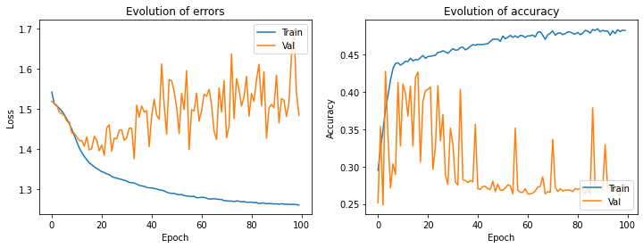

```python
plt.figure(figsize=(12,4))

plt.subplot(1,2,1)
plt.plot(hist.history['loss'])
plt.plot(hist.history['val_loss'])
plt.ylabel('Loss')
plt.xlabel('Epoch')
plt.legend(['Train', 'Val'], loc='upper right')
plt.title('Evolution of errors')

plt.subplot(1,2,2)
plt.plot(hist.history['accuracy'])
plt.plot(hist.history['val_accuracy'])
plt.ylabel('Accuracy')
plt.xlabel('Epoch')
plt.legend(['Train', 'Val'], loc='lower right')
plt.title('Evolution of accuracy')
```

**Model with regularization**

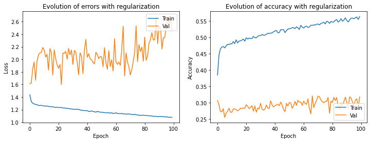

```python
plt.figure(figsize=(12,4))

plt.subplot(1,2,1)
plt.plot(hist_reg.history['loss'])
plt.plot(hist_reg.history['val_loss'])
plt.ylabel('Loss')
plt.xlabel('Epoch')
plt.legend(['Train', 'Val'], loc='upper right')
plt.title('Evolution of errors with regularization')

plt.subplot(1,2,2)
plt.plot(hist_reg.history['accuracy'])
plt.plot(hist_reg.history['val_accuracy'])
plt.ylabel('Accuracy')
plt.xlabel('Epoch')
plt.legend(['Train', 'Val'], loc='lower right')
plt.title('Evolution of accuracy with regularization')
```

**Model with regularization L2 and drop out**

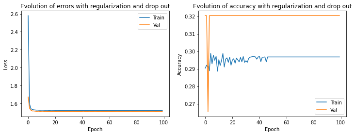

```python
plt.figure(figsize=(12,4))

plt.subplot(1,2,1)
plt.plot(hist_reg_drop.history['loss'])
plt.plot(hist_reg_drop.history['val_loss'])
plt.ylabel('Loss')
plt.xlabel('Epoch')
plt.legend(['Train', 'Val'], loc='upper right')
plt.title('Evolution of errors with regularization and drop out')

plt.subplot(1,2,2)
plt.plot(hist_reg_drop.history['accuracy'])
plt.plot(hist_reg_drop.history['val_accuracy'])
plt.ylabel('Accuracy')
plt.xlabel('Epoch')
plt.legend(['Train', 'Val'], loc='lower right')
plt.title('Evolution of accuracy with regularization and drop out')
```

We could conclude that we can improve our model by chosing the regularization model by:

- adding neurons
- adding epochs

### Improvement of the model

```python
nb_neurons = 50

model_opti = Sequential([
    Dense(nb_neurons, activation='relu', input_shape=(X_train.shape[1],)), #Input layer
    Dense(nb_neurons, activation='relu'), #Hidden layer 1
    Dense(nb_neurons, activation='relu'), #Hidden layer 2
    Dense(nb_neurons, activation='relu'), #Hidden layer 3
    Dense(Y_train.shape[1], activation='softmax'), #Output layer
])
```

```python
model_opti.compile(optimizer='adam',
              loss='categorical_crossentropy',
              metrics=['accuracy'])
```

```python
n_batch = 32
n_epochs = 200

hist_opti = model_opti.fit(X_train, Y_train,
          batch_size=n_batch, epochs=n_epochs,
          validation_data=(X_val, Y_val))
```

```python
print('Model performance:')
print('\nModel error:',model_opti.evaluate(X_test, Y_test)[0])
print('\nModel accuracy:',model_opti.evaluate(X_test, Y_test)[1]*100,'%')
```

```
Model performance:

Model error: 3.299973964691162

Model accuracy: 35.628741979599 %
```

### Plot of optimized model

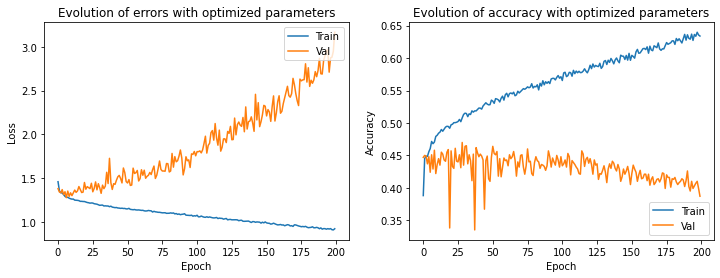

```python
plt.figure(figsize=(12,4))

plt.subplot(1,2,1)
plt.plot(hist_opti.history['loss'])
plt.plot(hist_opti.history['val_loss'])
plt.ylabel('Loss')
plt.xlabel('Epoch')
plt.legend(['Train', 'Val'], loc='upper right')
plt.title('Evolution of errors with optimized parameters')

plt.subplot(1,2,2)
plt.plot(hist_opti.history['accuracy'])
plt.plot(hist_opti.history['val_accuracy'])
plt.ylabel('Accuracy')
plt.xlabel('Epoch')
plt.legend(['Train', 'Val'], loc='lower right')
plt.title('Evolution of accuracy with optimized parameters')
```

### Conclusion

After this work, we obtained a model with:

- **loss : 3.3**
- **accuracy rate : 35%**

This is an acceptable accuracy but this model is disturbed by **overfitting issues**.